# Homework 6

Author

Nicole Friedl

Published

March 2, 2025

## Part 1: Data Analysis

An astrology professor Starry Ringo has an unprecedented desire to empirically assess the training she provides entitled, “Celestial Bodies and their Influence in Daily Life.” She asks 400 students on day 1 of her course to complete scale of her own devising, which she calls “Global Well-Being.” This scale is comprised of 4 subscales about subjective well-being, sense of self- clarity, sense of oneness with the world, and perceptions of harmony on Earth. She then randomly assigns each student to either receive her training or a control group. Then, students were asked to complete the Global Well-Being scale a second time 1 week after the training ends. She expects that, on average, students in the training group, who focused on understanding how the movement of the planets and stars affect their body chemistry, will have a greater increase in Global Well-Being than those who were placed in the control group and lack this knowledge.

Note: This study and its results are made up. In reality, we do not expect stars to have any bearing on our well-being

**Codebook:**

```r
options(conflicts.policy = "depends.ok")
library(tidyverse)
library(Matrix, exclude = c("expand", "pack", "unpack"))
library(lme4)
library(broom)
library(skimr)
library(car, exclude = c("recode", "some"))
library(ggplot2)
library(janitor)

path_data <- "homework/data"
devtools::source_url("https://github.com/jjcurtin/lab_support/blob/main/case_analysis.R?raw=true")
```

## 1. Read in the data. Explore univariate descriptive statistics

```r
data <- read_csv(here::here(path_data, "hw_6_data_long.csv"),
              show_col_types = FALSE) |>
  janitor::clean_names()
  glimpse(data)
```

```
Rows: 3,200
Columns: 6
$ id        <dbl> 1, 1, 1, 1, 1, 1, 1, 1, 2, 2, 2, 2, 2, 2, 2, 2, 3, 3, 3, 3, …
$ condition <chr> "control", "control", "control", "control", "control", "cont…
$ time      <chr> "pre", "post", "pre", "post", "pre", "post", "pre", "post", …
$ gwb       <dbl> 16.25708, 14.35267, 16.75708, 14.85267, 15.75708, 13.85267, …
$ zodiac    <chr> "pisces", "pisces", "pisces", "pisces", "pisces", "pisces", …
$ subscale  <dbl> 1, 1, 2, 2, 3, 3, 4, 4, 1, 1, 2, 2, 3, 3, 4, 4, 1, 1, 2, 2, …
```

## 2. Tabulate the mean Global Well-Being (GWB) scores across the time points and training conditions (so you should report 2x2 = 4 means total).

```r
gwb_means <- data |>
  group_by(time, condition) |>
  summarize(mean_gwb = mean(gwb, na.rm = TRUE),
            .groups = "drop")

glimpse(gwb_means)
```

```
Rows: 4
Columns: 3
$ time      <chr> "post", "post", "pre", "pre"
$ condition <chr> "control", "training", "control", "training"
$ mean_gwb  <dbl> 39.18048, 43.28348, 39.26811, 42.41350
```

## 3. Center the time and condition variables around -0.5 and 0.5

```r
data <- data |>
  mutate(
    time_c = ifelse(time == -1, -0.5, 0.5),
    condition_c = ifelse(condition == 0, -0.5, 0.5)
  )
```

## 4. For the first 12 subjects, plot subject-level data using ggplot. Remember to make sure the variables have informative names, but the plot does not have to be publication-quality

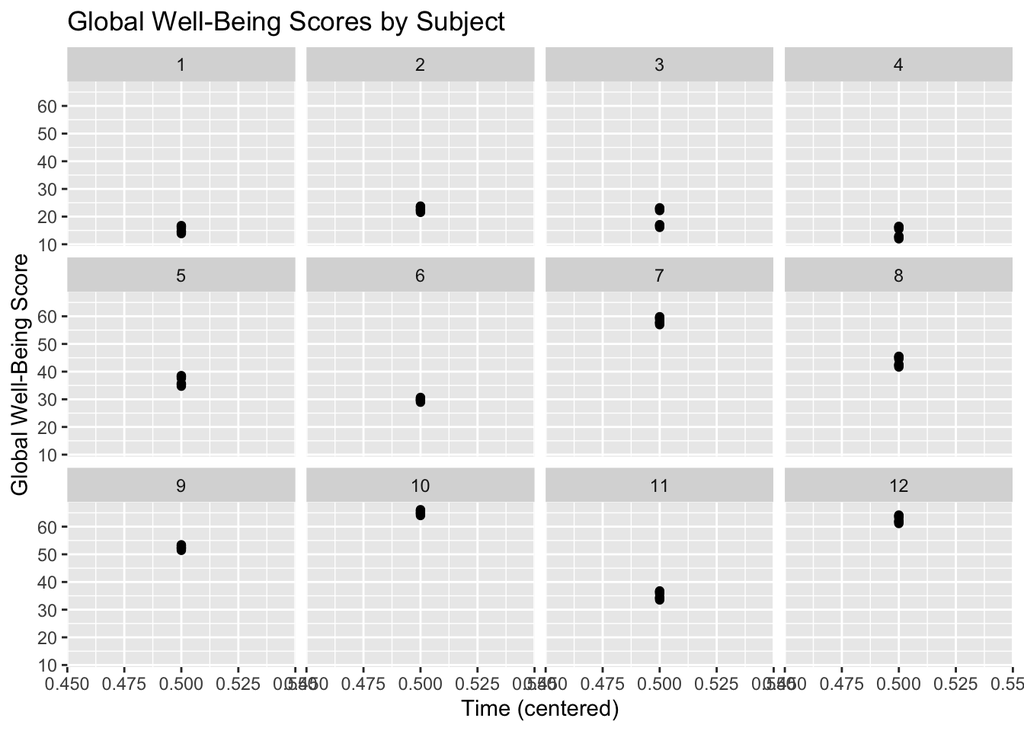

```r
ggplot(data = data |>  filter(id <= 12),
       aes(x = time_c, y = gwb)) +
  geom_point() +
  geom_smooth(method = "lm", se = FALSE) +
  facet_wrap(~id) +
  labs(
    title = "Global Well-Being Scores by Subject",
    x = "Time (centered)",
    y = "Global Well-Being Score"
  )
```

## 5. Convert the data from long to wide format. Ensure that your columns have sensible names in the wide format data file. Keep any other variables that are present, the astrologer wants to analyze them later but isn’t sure how to transform data herself. (You may need to use the pivot_wider() function more than once to fully transform your data into wide format)

```r
data_wide <- data |>
  select(-time_c, -condition_c) |>
  pivot_wider(names_from = c('time', 'subscale'),
              values_from = 'gwb')
```

## 6. Using the wide format data, create an average post-test GWB score and an average pre- test GWB score (remember that your average GWB score should by calculated from the 4 subscales). Calculate a difference score by subtracting the average pre-test GWB scores from post-test GWB scores.

```r
data_wide_avg <- data_wide %>%
  mutate(
    avg_pre_gwb = rowMeans(select(cur_data(), starts_with("pre_")), na.rm = TRUE),
    avg_post_gwb = rowMeans(select(cur_data(), starts_with("post_")), na.rm = TRUE),
    diff_gwb = avg_post_gwb - avg_pre_gwb
  )
head(data_wide_avg)
```

```
# A tibble: 6 × 14
     id condition zodiac  pre_1 post_1 pre_2 post_2 pre_3 post_3 pre_4 post_4
  <dbl> <chr>     <chr>   <dbl>  <dbl> <dbl>  <dbl> <dbl>  <dbl> <dbl>  <dbl>
1     1 control   pisces   16.3   14.4  16.8   14.9  15.8   13.9  16.5   14.6
2     2 training  taurus   22.0   23.3  22.5   23.8  21.5   22.8  22.3   23.6
3     3 control   gemini   22.7   16.6  23.2   17.1  22.2   16.1  22.9   16.8
4     4 training  libra    16.0   12.5  16.5   13.0  15.5   12.0  16.2   12.7
5     5 control   scorpio  38.1   35.2  38.6   35.7  37.6   34.7  38.3   35.5
6     6 training  virgo    30.2   29.4  30.7   29.9  29.7   28.9  30.4   29.7
# ℹ 3 more variables: avg_pre_gwb <dbl>, avg_post_gwb <dbl>, diff_gwb <dbl>
```

## 7. Test the effect of training on post-test scores using the ANCOVA method. Run the appropriate model. Is the astrologer’s hypothesis supported? Report relevant statistics. What is the coefficient for pre-test GWB score? How do you interpret that coefficient? What does this coefficient tell you about the statistical power of the ANCOVA vs. other approaches?

```r
m_ancova <- lm(avg_post_gwb ~ condition + avg_pre_gwb, data = data_wide_avg)
summary(m_ancova)
```

```
Call:
lm(formula = avg_post_gwb ~ condition + avg_pre_gwb, data = data_wide_avg)

Residuals:
    Min      1Q  Median      3Q     Max
-8.7645 -1.3874 -0.0849  1.3949  6.8566

Coefficients:
                   Estimate Std. Error t value Pr(>|t|)
(Intercept)       -0.115161   0.324949  -0.354    0.723
conditiontraining  0.955411   0.214064   4.463 1.05e-05 ***
avg_pre_gwb        1.000701   0.007334 136.441  < 2e-16 ***
---
Signif. codes:  0 '***' 0.001 '**' 0.01 '*' 0.05 '.' 0.1 ' ' 1

Residual standard error: 2.128 on 397 degrees of freedom
Multiple R-squared:  0.9795,    Adjusted R-squared:  0.9794
F-statistic:  9494 on 2 and 397 DF,  p-value: < 2.2e-16
```

```r
anova(m_ancova)
```

```
Analysis of Variance Table

Response: avg_post_gwb
             Df Sum Sq Mean Sq F value    Pr(>F)
condition     1   1683    1683   371.7 < 2.2e-16 ***
avg_pre_gwb   1  84315   84315 18616.2 < 2.2e-16 ***
Residuals   397   1798       5
---
Signif. codes:  0 '***' 0.001 '**' 0.01 '*' 0.05 '.' 0.1 ' ' 1
```

## 9. Create a publication quality graph for your ANCOVA model. Use your best judgment in determining what predictors to put on what axis, if you want to hold any predictors constant, etc.

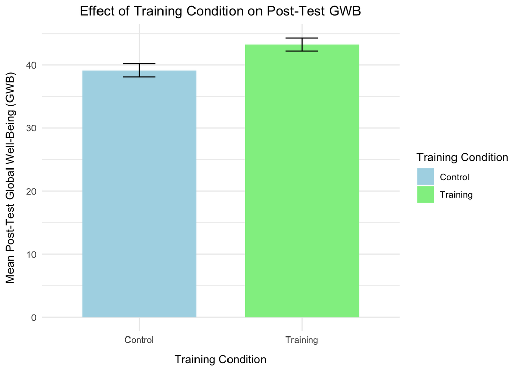

```r
plot_data <- data_wide_avg |>
  group_by(condition) |>
  summarise(
    mean_post_gwb = mean(avg_post_gwb, na.rm = TRUE),
    se_post_gwb = sd(avg_post_gwb, na.rm = TRUE) / sqrt(n())
  )

ggplot(plot_data, aes(x = factor(condition), y = mean_post_gwb, fill = factor(condition))) +
  geom_bar(stat = "identity", position = position_dodge(width = 0.9), width = 0.7) +
  geom_errorbar(aes(ymin = mean_post_gwb - se_post_gwb, ymax = mean_post_gwb + se_post_gwb),
                width = 0.2, position = position_dodge(width = 0.9)) +
  labs(
    title = "Effect of Training Condition on Post-Test GWB",
    x = "Training Condition",
    y = "Mean Post-Test Global Well-Being (GWB)",
    fill = "Training Condition"
  ) +
  scale_x_discrete(labels = c("Control", "Training")) +
  scale_fill_manual(values = c("lightblue", "lightgreen"), labels = c("Control", "Training")) +
  theme_minimal() +
  theme(
    plot.title = element_text(hjust = 0.5),
    legend.position = "right",
    axis.title.x = element_text(margin = margin(t = 10)),
    axis.title.y = element_text(margin = margin(r = 10))
  )
```

## 10. Now imagine another change to the procedure. Students in the courses complete the GWB scale. The courses with an average score of 50 and above take part in secondary course in which they receive training. After the end of the training all students in the course complete the GWB scale again. Does this change in procedure affect the appropriate data-analytic strategy, yes or no? Justify your answer in one or two sentences. If you answer yes, explain what in your view the appropriate data analytic strategy is.

Yes, this change significantly affects the data-analytic strategy. The new procedure introduces a non-random assignment to the training group based on pre-test scores, violating the assumption of independence between the covariate (pre-test score) and the treatment condition, making a standard ANCOVA inappropriate. A more appropriate strategy would be a regression discontinuity design (RDD) if the cutoff of 50 is strictly enforced, or a propensity score matching approach to address the selection bias.

## 11. A group of researchers are interested in testing whether interpersonal psychotherapy and whether the use of a mindfulness mobile app reduces depressive symptoms. 20 patients are recruited from each of the 30 local psychological clinics resulting in a sample of 600 individuals. Half of the clinics were randomly assigned to engage their patients in using the mindfulness app, while the other half did not provide the mindfulness app. In each clinic, half of the patients were randomly assigned to psychotherapy, and the other half to treatment as usual (i.e., control condition). Depressive symptoms were measured at two times: once before intervention and once 8 weeks into the intervention. Write out the level 1 & 2 equations for the model that the researchers would want to fit.

Level 1: Depression_tij = β0ij + β1ij * Time_tij + e_tij

Level 2: β0ij = γ00 + γ01 * Psychotherapy_ij + γ02 * Mindfulness_j + γ03 * (Psychotherapy_ij * Mindfulness_j) + u0j + r0ij β1ij = γ10 + γ11 * Psychotherapy_ij + γ12 * Mindfulness_j + γ13 * (Psychotherapy_ij * Mindfulness_j) + u1j + r1ij

## 12. How long did this assignment take you?

4 hours

## 13. If you used ChatGPT or any other LLM while working on this homework, please indicate so below. Please list all commands that you provided the LLM with and its responses.

I tried to use it to help me do the pivot_wider section. Although, not very helpful. I kept getting errors so I deleted it and enlisted the help of https://tidyr.tidyverse.org/reference/pivot_wider.html.